# About:

This notebook was created by me as part of an independent data analysis project.

The purpose of this project is to discover which factors are the most important in determining the price of an Airbnb listing in NYC.

This exploratory data analysis (EDA) has been conducted and completed entirely by me, Zamin Abbas, using the publicly available Airbnb dataset from Kaggle. The dataset can be accessed here: [NYC Airbnb Open Data](https://www.kaggle.com/datasets/dgomonov/new-york-city-airbnb-open-data).

The analysis aims to uncover meaningful insights, identify key price drivers, and understand the underlying patterns within the NYC Airbnb market.

# Preparation

```python
import pandas as pd

df = pd.read_csv("/content/airbnb_data.csv")

df
```

|  | id | name | host_id | host_name | neighbourhood_group | neighbourhood | latitude | longitude | room_type | price | minimum_nights | number_of_reviews | last_review | reviews_per_month | calculated_host_listings_count | availability_365 |
| --- | --- | --- | --- | --- | --- | --- | --- | --- | --- | --- | --- | --- | --- | --- | --- | --- |
| 0 | 2539 | Clean & quiet apt home by the park | 2787 | John | Brooklyn | Kensington | 40.64749 | -73.97237 | Private room | 149 | 1 | 9 | 2018-10-19 | 0.21 | 6 | 365 |
| 1 | 2595 | Skylit Midtown Castle | 2845 | Jennifer | Manhattan | Midtown | 40.75362 | -73.98377 | Entire home/apt | 225 | 1 | 45 | 2019-05-21 | 0.38 | 2 | 355 |
| 2 | 3647 | THE VILLAGE OF HARLEM....NEW YORK ! | 4632 | Elisabeth | Manhattan | Harlem | 40.80902 | -73.94190 | Private room | 150 | 3 | 0 | NaN | NaN | 1 | 365 |
| 3 | 3831 | Cozy Entire Floor of Brownstone | 4869 | LisaRoxanne | Brooklyn | Clinton Hill | 40.68514 | -73.95976 | Entire home/apt | 89 | 1 | 270 | 2019-07-05 | 4.64 | 1 | 194 |
| 4 | 5022 | Entire Apt: Spacious Studio/Loft by central park | 7192 | Laura | Manhattan | East Harlem | 40.79851 | -73.94399 | Entire home/apt | 80 | 10 | 9 | 2018-11-19 | 0.10 | 1 | 0 |
| ... | ... | ... | ... | ... | ... | ... | ... | ... | ... | ... | ... | ... | ... | ... | ... | ... |
| 48890 | 36484665 | Charming one bedroom - newly renovated rowhouse | 8232441 | Sabrina | Brooklyn | Bedford-Stuyvesant | 40.67853 | -73.94995 | Private room | 70 | 2 | 0 | NaN | NaN | 2 | 9 |
| 48891 | 36485057 | Affordable room in Bushwick/East Williamsburg | 6570630 | Marisol | Brooklyn | Bushwick | 40.70184 | -73.93317 | Private room | 40 | 4 | 0 | NaN | NaN | 2 | 36 |
| 48892 | 36485431 | Sunny Studio at Historical Neighborhood | 23492952 | Ilgar & Aysel | Manhattan | Harlem | 40.81475 | -73.94867 | Entire home/apt | 115 | 10 | 0 | NaN | NaN | 1 | 27 |
| 48893 | 36485609 | 43rd St. Time Square-cozy single bed | 30985759 | Taz | Manhattan | Hell's Kitchen | 40.75751 | -73.99112 | Shared room | 55 | 1 | 0 | NaN | NaN | 6 | 2 |
| 48894 | 36487245 | Trendy duplex in the very heart of Hell's Kitchen | 68119814 | Christophe | Manhattan | Hell's Kitchen | 40.76404 | -73.98933 | Private room | 90 | 7 | 0 | NaN | NaN | 1 | 23 |

48895 rows × 16 columns

## Data Cleaning

```python
df = df.drop(['id', 'name', 'host_name', 'neighbourhood',
              'last_review', 'reviews_per_month',
              'calculated_host_listings_count'], axis = 1)

df = df[(df['price'] > 10) & (df['price'] < 2000)]

df.head(2)
```

|  | host_id | neighbourhood_group | latitude | longitude | room_type | price | minimum_nights | number_of_reviews | availability_365 |
| --- | --- | --- | --- | --- | --- | --- | --- | --- | --- |
| 0 | 2787 | Brooklyn | 40.64749 | -73.97237 | Private room | 149 | 1 | 9 | 365 |
| 1 | 2845 | Manhattan | 40.75362 | -73.98377 | Entire home/apt | 225 | 1 | 45 | 355 |

# Analysis

```python
len(df)
```

```
48757
```

```python
df['price'].describe()
```

|  | price |
| --- | --- |
| count | 48757.000000 |
| mean | 144.666899 |
| std | 133.740858 |
| min | 11.000000 |
| 25% | 69.000000 |
| 50% | 105.000000 |
| 75% | 175.000000 |
| max | 1999.000000 |

**dtype:** float64

```python
df.corr(numeric_only=True)['price']
```

|  | price |
| --- | --- |
| host_id | 0.030558 |
| latitude | 0.054463 |
| longitude | -0.239443 |
| price | 1.000000 |
| minimum_nights | 0.024649 |
| number_of_reviews | -0.059204 |
| availability_365 | 0.113562 |

**dtype:** float64

# Geographical Area

```python
avg_prices = df.groupby('neighbourhood_group')['price'].mean().sort_values(ascending = False)

avg_prices
```

| neighbourhood_group | price |
| --- | --- |
| Manhattan | 184.245516 |
| Brooklyn | 119.755084 |
| Staten Island | 101.680108 |
| Queens | 96.303818 |
| Bronx | 85.431066 |

**dtype:** float64

# Room Type

```python
avg_room_type_price = df.groupby('room_type')['price'].mean().sort_values(ascending = False)

avg_room_type_price
```

| room_type | price |
| --- | --- |
| Entire home/apt | 199.363690 |
| Private room | 86.416087 |
| Shared room | 70.352941 |

**dtype:** float64

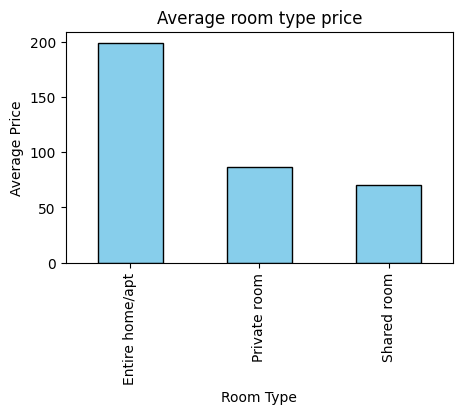

```python
import matplotlib.pyplot as plt

plt.figure(figsize = (5,3))

avg_room_type_price.plot(kind = 'bar', color = 'skyblue', edgecolor = 'black')

plt.title('Average room type price')
plt.xlabel('Room Type')
plt.ylabel('Average Price')
plt.show()
```

# Availability

```python
avg_price_always_available = df[df['availability_365'] == 365]['price'].mean()

avg_price_not_always_available = df[df['availability_365'] != 365]['price'].mean()

print('Average price of the rooms that are always available:', avg_price_always_available)
print('Average price of the rooms that are not always available, but have availability:', avg_price_not_always_available)
```

```
Average price of the rooms that are always available: 201.7981220657277
Average price of the rooms that are not always available, but have availability: 143.12908864971882
```

# Key Findings

According to the data, the most expensive Airbnb listings in New York City tend to be entire home/apartment rentals located in Manhattan — sitting right at the heart of the city. This comes as little surprise, given Manhattan's prime location, iconic neighborhoods, and the unmatched access it offers to some of the world's most sought-after attractions. Guests paying a premium aren't just renting a space — they're buying into the full New York City experience.

```python
!jupyter nbconvert --to html notebook.ipynb
```

```
[NbConvertApp] Converting notebook notebook.ipynb to html
[NbConvertApp] WARNING | Alternative text is missing on 1 image(s).
[NbConvertApp] Writing 337756 bytes to notebook.html
```